# Insurance_Fraud_Prediction_Scikit-Learn

## Myth: Fraud is a victimless crime.

## Reality : Insurance fraud is one of the biggest crimes in the U.S.

- Every year claims and underwriting fraud cost **$80 billion**
- Fraudulent claims account for **5-10%** of all claims

[figure not shown]

## Impact of Fraud

- Fraudulent claims directly impact Loss Ratio, thereby, reducing profitability and also negatively impacting Return on Equity (ROE)
- Fraudulent claims add to premium costs, since insurers are compelled to pass on the cost of such claims to policyholders

## Business Need

- Control dishonest claims payout through better fraud detection techniques
- Automation of Fraud Detection Approach making better use of data

[figure not shown]

Detecting insurance fraud poses an interesting problem from a data science perspective as the problem becomes a binary classification problem in which our “response” variable is “Y” or “N” — claim is fraudulent or not.

[figure not shown]

We'll demonstrate an attempt to solve this problem by using an auto insurance dataset containing 1000 observations on 39 features, and using this data to train a classifier to be able to predict whether a particular claim is fraudulent or not.

The [dataset](https://databricks-prod-cloudfront.cloud.databricks.com/public/4027ec902e239c93eaaa8714f173bcfc/4954928053318020/1058911316420443/167703932442645/latest.html) is made available by APN Partner - [Databricks](https://databricks.com/), a company that provides an unified analytics platform, nuifying data science and engineering across the Machine Learning lifecycle.

```python
import numpy as np
import pandas as pd
import matplotlib.pyplot as plt

data = pd.read_csv("insurance_claims.csv")
```

## Data exploration

Display number of observations (rows) and features (columns)

```python
data.shape
```

```
(1000, 39)
```

Quick look at some sample observations reveal the dataset is not the cleanest:

- Some features have wide variations in values
- Some features have missing values
- There is a mix of numberic and categorical features

```python
data.head(10)
```

|  | months_as_customer | age | policy_number | policy_bind_date | policy_state | policy_csl | policy_deductable | policy_annual_premium | umbrella_limit | insured_zip | ... | witnesses | police_report_available | total_claim_amount | injury_claim | property_claim | vehicle_claim | auto_make | auto_model | auto_year | fraud_reported |
| --- | --- | --- | --- | --- | --- | --- | --- | --- | --- | --- | --- | --- | --- | --- | --- | --- | --- | --- | --- | --- | --- |
| 0 | 328 | 48 | 521585 | 2014-10-17 | OH | 250/500 | 1000 | 1406.91 | 0 | 466132 | ... | 2 | YES | 71610 | 6510 | 13020 | 52080 | Saab | 92x | 2004 | Y |
| 1 | 228 | 42 | 342868 | 2006-06-27 | IN | 250/500 | 2000 | 1197.22 | 5000000 | 468176 | ... | 0 | ? | 5070 | 780 | 780 | 3510 | Mercedes | E400 | 2007 | Y |
| 2 | 134 | 29 | 687698 | 2000-09-06 | OH | 100/300 | 2000 | 1413.14 | 5000000 | 430632 | ... | 3 | NO | 34650 | 7700 | 3850 | 23100 | Dodge | RAM | 2007 | N |
| 3 | 256 | 41 | 227811 | 1990-05-25 | IL | 250/500 | 2000 | 1415.74 | 6000000 | 608117 | ... | 2 | NO | 63400 | 6340 | 6340 | 50720 | Chevrolet | Tahoe | 2014 | Y |
| 4 | 228 | 44 | 367455 | 2014-06-06 | IL | 500/1000 | 1000 | 1583.91 | 6000000 | 610706 | ... | 1 | NO | 6500 | 1300 | 650 | 4550 | Accura | RSX | 2009 | N |
| 5 | 256 | 39 | 104594 | 2006-10-12 | OH | 250/500 | 1000 | 1351.10 | 0 | 478456 | ... | 2 | NO | 64100 | 6410 | 6410 | 51280 | Saab | 95 | 2003 | Y |
| 6 | 137 | 34 | 413978 | 2000-06-04 | IN | 250/500 | 1000 | 1333.35 | 0 | 441716 | ... | 0 | ? | 78650 | 21450 | 7150 | 50050 | Nissan | Pathfinder | 2012 | N |
| 7 | 165 | 37 | 429027 | 1990-02-03 | IL | 100/300 | 1000 | 1137.03 | 0 | 603195 | ... | 2 | YES | 51590 | 9380 | 9380 | 32830 | Audi | A5 | 2015 | N |
| 8 | 27 | 33 | 485665 | 1997-02-05 | IL | 100/300 | 500 | 1442.99 | 0 | 601734 | ... | 1 | YES | 27700 | 2770 | 2770 | 22160 | Toyota | Camry | 2012 | N |
| 9 | 212 | 42 | 636550 | 2011-07-25 | IL | 100/300 | 500 | 1315.68 | 0 | 600983 | ... | 1 | ? | 42300 | 4700 | 4700 | 32900 | Saab | 92x | 1996 | N |

10 rows × 39 columns

```python
data.dtypes
```

```
months_as_customer               int64
age                              int64
policy_number                    int64
policy_bind_date                object
policy_state                    object
policy_csl                      object
policy_deductable                int64
policy_annual_premium          float64
umbrella_limit                   int64
insured_zip                      int64
insured_sex                     object
insured_education_level         object
insured_occupation              object
insured_hobbies                 object
insured_relationship            object
capital-gains                    int64
capital-loss                     int64
incident_date                   object
incident_type                   object
collision_type                  object
incident_severity               object
authorities_contacted           object
incident_state                  object
incident_city                   object
incident_location               object
incident_hour_of_the_day         int64
number_of_vehicles_involved      int64
property_damage                 object
bodily_injuries                  int64
witnesses                        int64
police_report_available         object
total_claim_amount               int64
injury_claim                     int64
property_claim                   int64
vehicle_claim                    int64
auto_make                       object
auto_model                      object
auto_year                        int64
fraud_reported                  object
dtype: object
```

```python
stringCols = []
for i,t in enumerate(data.dtypes):
    if t == 'object':
        stringCols.append(data.columns[i])

for col in stringCols:
    print("{} : {}".format(col, len(data.groupby(col).policy_number.nunique())))
```

```
policy_bind_date : 951
policy_state : 3
policy_csl : 3
insured_sex : 2
insured_education_level : 7
insured_occupation : 14
insured_hobbies : 20
insured_relationship : 6
incident_date : 60
incident_type : 4
collision_type : 4
incident_severity : 4
authorities_contacted : 5
incident_state : 7
incident_city : 7
incident_location : 1000
property_damage : 3
police_report_available : 3
auto_make : 14
auto_model : 39
fraud_reported : 2
```

Based on a count of categorical variables, it can be seen that following fields have too many categories, hence cannot be encoded into numeric values meaningfully.

- `policy_bind_date`
- `incident_date`
- `incident_location`

Among numeric columns, `insured_zip` is in reality a categorical value, and cannot be encoded meaningfully.

In addition, `policy_number` serves as an idnetifier, and likely have no effect on a claim being fraudulent or not.

These columns are therefore removed, for the sake of simplicity.

```python
colsToDelete = ["policy_number", "policy_bind_date", "insured_zip", "incident_location", "incident_date"]

for col in colsToDelete:
    del data[col]
```

Remaining columns will be encoded later.

```python
filteredStringColList = [i for i in stringCols if i not in colsToDelete]
print(filteredStringColList)
```

[output not shown]

The target variable, to be predicted is `fraud-reported`. Plotting the count of observations belonging the two classes `Y` and `N` also reveals a large imbalance.

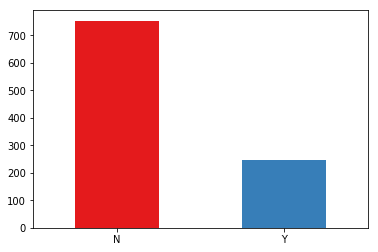

```python
data['fraud_reported'].value_counts().plot(kind='bar', color=plt.cm.Set1(np.arange(len(data))), rot=1)
```

Plotting the claims data on a map provides a nice visual on which area are more rpone to insurance claims, which could prove to be a valuable insight.

```python
data['incident_state'].value_counts()
```

```
NY    262
SC    248
WV    217
NC    110
VA    110
PA     30
OH     23
Name: incident_state, dtype: int64
```

```python
data['incident_state_count'] = data['incident_state']
numCol = data.shape[1] -1
for i in range(len(data['incident_state_count'])):
    if data.iloc[i, numCol] == "NY":
        data.iloc[i, numCol] = 262
    if data.iloc[i, numCol] == "SC":
        data.iloc[i, numCol] = 248
    if data.iloc[i, numCol] == "WV":
        data.iloc[i, numCol] = 217
    if data.iloc[i, numCol] == "VA":
        data.iloc[i, numCol] = 110
    if data.iloc[i, numCol] == "NC":
        data.iloc[i, numCol] = 110
    if data.iloc[i, numCol] == "PA":
        data.iloc[i, numCol] = 30
    if data.iloc[i, numCol] == "OH":
        data.iloc[i, numCol] = 23
```

```python
#!pip install chart_studio
```

```python
import plotly.graph_objs as go

import chart_studio.plotly as cplt
import plotly.graph_objs as go

cplt.sign_in(username='binoyd', api_key='AqufAmuAZYO1iXQXPVnU')

plotdata = [go.Choropleth(autocolorscale = True, locations = data['incident_state'],
                      z = data['incident_state_count'],
                      locationmode = 'USA-states',
                      marker = go.choropleth.Marker(line = go.choropleth.marker.Line(color = 'rgb(255,255,255)', width = 2)),
                      colorbar = go.choropleth.ColorBar(title = "Number of Incidents"))]
layout = go.Layout(
    title = go.layout.Title(
        text = 'Insurance Incident Claims by State'
    ),
    geo = go.layout.Geo(
        scope = 'usa',
        projection = go.layout.geo.Projection(type = 'albers usa'),
        showlakes = True,
        lakecolor = 'rgb(255, 255, 255)'),
)

fig = go.Figure(data = plotdata, layout = layout)
cplt.iplot(fig, filename = 'd3-cloropleth-map')
```

[interactive chart not shown]

```python
del data['incident_state_count']
```

```python
import plotly.express as px
fig = px.bar(data, x='auto_year', y='total_claim_amount')
fig.show()
```

[interactive chart not shown]

Now the data is ready to split into `X` and `Y`, representing features and target, with categorical variables encoded into numeric ones.

Note, that number of columns go up, since each categorical column now gets expanded into a column for each of it's distinct values.

```python
X = data.loc[:, data.columns[0]:data.columns[data.shape[1]-2]]
X = pd.get_dummies(X)
Y = data[data.columns[data.shape[1]-1]]
Y = Y.replace("Y", 1)
Y = Y.replace("N", 0)
print(X.shape)
print(Y.shape)
```

```
(1000, 161)
(1000,)
```

## LogisticRegression - Random Cross-validation

The problem we have at hand now is a binary classification, where we have to predict observations into one of two classes - `1` or `0` (corresponding to whether a particular claim is identified as frauduent or not)

This can be achieved using different algorithms, such as LogisticRegression, RandomForest, DecisionTree, SVM, etc., with various hyper-paramaeters, such as penalty function used, number of estimators, maximum depth of tree etc.

Before doing a full Grid search, our first attempt is to run a Logistic Regression model through grid search and random cross validation, using Scikit-learn libraries, that are computationally inexpensive.

Grid search is performed using a LogisticRegresion learner with `lblinear` solver, with hyperparameter space defined over penalty (L1 and L2 norms) and inverse regularization strenth ( 0 to 10, with $1/10^6$ fold increments)

```python
%%time
from scipy.stats import uniform
from sklearn import linear_model, datasets
from sklearn.model_selection import RandomizedSearchCV
import warnings
warnings.filterwarnings("ignore", category=DeprecationWarning)
warnings.simplefilter(action='ignore', category=FutureWarning)

def perform_randomized_search(features, target, model, hyperparams, kFolds):
    randomizedsearch = RandomizedSearchCV(model, hyperparams, cv = kFolds, verbose=1)
    best_model = randomizedsearch.fit(features, target)
    print("The mean accuracy of the model is:",best_model.score(features, target))
    print("The best parameters for the model are:",best_model.best_params_)
    return best_model

logistic = linear_model.LogisticRegression(class_weight = 'balanced', solver='liblinear', max_iter=100)
norms = ['l1', 'l2']
C = np.random.uniform(0, 10, 100000)
hyperparameters = dict(C=C, penalty=norms)
model = perform_randomized_search(X, Y, logistic, hyperparameters, 10)
```

```
Fitting 10 folds for each of 10 candidates, totalling 100 fits
```

```
[Parallel(n_jobs=1)]: Using backend SequentialBackend with 1 concurrent workers.
```

```
The mean accuracy of the model is: 0.88
The best parameters for the model are: {'penalty': 'l1', 'C': 2.2014271313563083}
CPU times: user 17.9 s, sys: 552 ms, total: 18.4 s
Wall time: 4.63 s
```

```
[Parallel(n_jobs=1)]: Done 100 out of 100 | elapsed:    4.6s finished
```

## Classification report - Logistic Regression

As a result of this grid search, we obtain a model that yields an accuracy of close to 88%.

However accuracy in itself is not of much value, specially when dealing with classification with imbalanced classes. In this particular case, as we saw earlier, there is a large imbalance where much more claims are identified to be not fraudulent in training data than the ones that are reported to be fraudulent.

In reality, insurance industry would prefer to predict as many true negatives (under represented class) to minimize the loss.

So we create a classification report to see how our Logistic Regression model performed in predicting both classes.

```python
from sklearn.model_selection import train_test_split
from sklearn.metrics import classification_report


X_train, X_test, y_train, y_test = train_test_split(X, Y, test_size=0.3, random_state=30)

logReg = linear_model.LogisticRegression(C=2.2014271313563083, penalty='l1', solver='liblinear')
logReg.fit(X_train, y_train)
y_pred = logReg.predict(X_test)

print(classification_report(y_test, y_pred))
```

```
              precision    recall  f1-score   support

           0       0.88      0.91      0.89       233
           1       0.63      0.55      0.59        67

   micro avg       0.83      0.83      0.83       300
   macro avg       0.75      0.73      0.74       300
weighted avg       0.82      0.83      0.82       300
```

Even though the preliminary test looks good, and feels like we can proceed to productionize this model with Logistic regression, it would be prudent to do a search on other algortihms avaiable for the task.

## GridSearch with Pipeline

Instead of running different classifiers separately and comparining the outcomes manually, in Scikit learn we can use Pipeline feature with a list of classifiers.

We then conduct a Grid search over the algorithms and hyperparameters specified for each.

```python
%%time
from sklearn.pipeline import Pipeline
from sklearn.linear_model import LogisticRegression
from sklearn.ensemble import RandomForestClassifier
from sklearn.tree import DecisionTreeClassifier
## We will include our logistic regression models in addition to RandomForestClassifier and DecisionTreeClassifier

models = [
    {
        "classifier": [LogisticRegression()],
        "classifier__penalty": ['l2','l1'],
        "classifier__C": np.logspace(0, 10, 50)
    },
    {
        "classifier": [LogisticRegression()],
        "classifier__penalty": ['l2'],
        "classifier__C": np.logspace(0, 10, 50),
        "classifier__solver":['newton-cg','saga','sag','liblinear']
    },
    {
        "classifier": [RandomForestClassifier()],
        "classifier__n_estimators": [10, 100, 1000, 1000],
        "classifier__max_depth":[5,8,15,25,30,None],
        "classifier__min_samples_leaf":[1,2,5,10,15,100],
        "classifier__max_leaf_nodes": [2, 5,10]
    },
    {
        "classifier": [DecisionTreeClassifier()],
        "classifier__splitter":['best', 'random'],
        "classifier__max_depth":[5,8,15,25,30,None],
        "classifier__min_samples_leaf":[1,2,5,10,15,100],
        "classifier__max_leaf_nodes": [2, 5,10]
    },
    {
        "classifier": [DecisionTreeClassifier(class_weight = 'balanced')],
        "classifier__splitter":['best', 'random'],
        "classifier__max_depth":[5,8,15,25,30,None],
        "classifier__min_samples_leaf":[1,2,5,10,15,100],
        "classifier__max_leaf_nodes": [2, 5,10]
    }
]
```

```
CPU times: user 8.4 ms, sys: 4.02 ms, total: 12.4 ms
Wall time: 12 ms
```

```python
from sklearn.model_selection import GridSearchCV
def execute_pipeline(features,target, model_list, kFolds):
    pipe = Pipeline([("classifier", RandomForestClassifier())])
    gridsearch = GridSearchCV(pipe, model_list, cv=kFolds, verbose=1, n_jobs=-1) # Fit grid search
    best_model = gridsearch.fit(features, target)
    print("The mean accuracy of the model is:",best_model.score(features, target))
    print("The best parameters for the model are:",best_model.best_params_)
    return best_model


model = execute_pipeline(X, Y, models, 10)
```

```
Fitting 10 folds for each of 1164 candidates, totalling 11640 fits
```

[output not shown]

```
The mean accuracy of the model is: 0.861
The best parameters for the model are: {'classifier': DecisionTreeClassifier(class_weight=None, criterion='gini', max_depth=5,
            max_features=None, max_leaf_nodes=5, min_impurity_decrease=0.0,
            min_impurity_split=None, min_samples_leaf=10,
            min_samples_split=2, min_weight_fraction_leaf=0.0,
            presort=False, random_state=None, splitter='random'), 'classifier__max_depth': 5, 'classifier__max_leaf_nodes': 5, 'classifier__min_samples_leaf': 10, 'classifier__splitter': 'random'}
```

```
[Parallel(n_jobs=-1)]: Done 11625 out of 11640 | elapsed: 11.4min remaining:    0.9s
[Parallel(n_jobs=-1)]: Done 11640 out of 11640 | elapsed: 11.4min finished
```

GridSearch finds Decision Tree Classifier to be the best performing model, although the accuracy of 86% is clearly lower than that of Logistic Regression.

But then again, only accuracy measure is not that relevant given teh class imbalance that we noticed for this dataset.

## Classification report - DecisionTreeClassifier

We therefore run a classification report using the identified classifier from GridSearch, so as to be able to compare it with the one obtained for Logistic Regression earlier.

```python
decT = DecisionTreeClassifier(class_weight=None, criterion='gini', max_depth=5,
            max_features=None, max_leaf_nodes=5, min_impurity_decrease=0.0,
            min_impurity_split=None, min_samples_leaf=10,
            min_samples_split=2, min_weight_fraction_leaf=0.0,
            presort=False, random_state=None, splitter='random')

decT.fit(X_train, y_train)
y_pred = decT.predict(X_test)
print(classification_report(y_test, y_pred))
```

```
              precision    recall  f1-score   support

           0       0.94      0.83      0.88       233
           1       0.59      0.82      0.68        67

   micro avg       0.83      0.83      0.83       300
   macro avg       0.76      0.83      0.78       300
weighted avg       0.86      0.83      0.84       300
```

Comparing the classification report, we discover that the Decision Tree classifier yields a much higher precision of 94% for sample class - `0` (NOT Fraudulent).

However, the precision for sample class - `1` (Fraudulent) is lower at 59% (as opposed to 63% as obtained from Logistic regression).

## Next Steps

With the insight derived thus far, we'll now proceed to create a SageMaker training and deployment pipeleine using one of the SageMaker native algorithm - Linear Learner Algorithm.

Linear Learner Algorithm can be used for either regression or classification. When used for Classification, it is essentially same as using a LogisticRegression classifier with `liblinear` solver.